# Assignment 2: Spatial Analysis and Visualization

Healthcare Access and Equity in Pennsylvania

Author

Tessa Vu

Published

October 14, 2025

## Assignment Overview

**Learning Objectives:**

- Apply spatial operations to answer policy-relevant research questions
- Integrate census demographic data with spatial analysis
- Create publication-quality visualizations and maps
- Work with spatial data from multiple sources
- Communicate findings effectively for policy audiences

## Part 1: Healthcare Access for Vulnerable Populations

### Research Question

**Which Pennsylvania counties have the highest proportion of vulnerable populations (elderly + low-income) living far from hospitals?**

Your analysis should identify counties that should be priorities for healthcare investment and policy intervention.

### Required Analysis Steps

Complete the following analysis, documenting each step with code and brief explanations:

#### Step 1: Data Collection (5 points)

Load the required spatial data:

- Pennsylvania county boundaries
- Pennsylvania hospitals (from lecture data)
- Pennsylvania census tracts

**Your Task:**

```r
# Load required packages
library(kableExtra)
library(knitr)
library(patchwork)
library(scales)
library(sf)
library(tibble)
library(tidycensus)
library(tidyverse)
library(tigris)
library(units)

# Set Census API key
census_api_key("3aaee31789e10b674a531e9f236c35d5394b19ed")

# Load spatial data
pa_counties <- st_read("data/Pennsylvania_County_Boundaries.shp")
pa_tracts <- tracts(state = "PA", cb = TRUE)
pa_hospitals <- st_read("data/hospitals.geojson")
# Check that all data loaded correctly
glimpse(pa_counties)
```

```
Rows: 67
Columns: 20
$ OBJECTID   <int> 336, 337, 338, 339, 340, 341, 342, 343, 344, 345, 346, 347,…
$ MSLINK     <int> 46, 8, 9, 58, 59, 60, 62, 63, 42, 43, 44, 47, 48, 49, 50, 5…
$ COUNTY_NAM <chr> "MONTGOMERY", "BRADFORD", "BUCKS", "TIOGA", "UNION", "VENAN…
$ COUNTY_NUM <chr> "46", "08", "09", "58", "59", "60", "62", "63", "42", "43",…
$ FIPS_COUNT <chr> "091", "015", "017", "117", "119", "121", "125", "127", "08…
$ COUNTY_ARE <chr> NA, NA, NA, NA, NA, NA, NA, NA, NA, NA, NA, NA, NA, NA, NA,…
$ COUNTY_PER <chr> NA, NA, NA, NA, NA, NA, NA, NA, NA, NA, NA, NA, NA, NA, NA,…
$ NUMERIC_LA <int> 5, 2, 5, 2, 2, 3, 1, 2, 1, 3, 1, 2, 2, 2, 2, 2, 2, 2, 2, 1,…
$ COUNTY_N_1 <int> 46, 8, 9, 58, 59, 60, 62, 63, 42, 43, 44, 47, 48, 49, 50, 5…
$ AREA_SQ_MI <dbl> 487.4271, 1161.3379, 622.0836, 1137.2480, 319.1893, 683.367…
$ SOUND      <chr> NA, NA, NA, NA, NA, NA, NA, NA, NA, NA, NA, NA, NA, NA, NA,…
$ SPREAD_SHE <chr> NA, NA, NA, NA, NA, NA, NA, NA, NA, NA, NA, NA, NA, NA, NA,…
$ IMAGE_NAME <chr> "poll.bmp", "poll.bmp", "poll.bmp", "poll.bmp", "poll.bmp",…
$ NOTE_FILE  <chr> NA, NA, NA, NA, NA, NA, NA, NA, NA, NA, NA, NA, NA, NA, NA,…
$ VIDEO      <chr> NA, NA, NA, NA, NA, NA, NA, NA, NA, NA, NA, NA, NA, NA, NA,…
$ DISTRICT_N <chr> "06", "03", "06", "03", "03", "01", "12", "04", "02", "01",…
$ PA_CTY_COD <chr> "46", "08", "09", "59", "60", "61", "63", "64", "42", "43",…
$ MAINT_CTY_ <chr> "4", "9", "1", "7", "8", "5", "4", "6", "5", "4", "7", "3",…
$ DISTRICT_O <chr> "6-4", "3-9", "6-1", "3-7", "3-8", "1-5", "12-4", "4-6", "2…
$ geometry   <MULTIPOLYGON [m]> MULTIPOLYGON (((-8398884 48..., MULTIPOLYGON (…
```

```r
glimpse(pa_tracts)
```

```
Rows: 3,445
Columns: 14
$ STATEFP    <chr> "42", "42", "42", "42", "42", "42", "42", "42", "42", "42",…
$ COUNTYFP   <chr> "001", "013", "013", "013", "013", "011", "011", "011", "01…
$ TRACTCE    <chr> "031101", "100400", "100500", "100800", "101900", "011200",…
$ GEOIDFQ    <chr> "1400000US42001031101", "1400000US42013100400", "1400000US4…
$ GEOID      <chr> "42001031101", "42013100400", "42013100500", "42013100800",…
$ NAME       <chr> "311.01", "1004", "1005", "1008", "1019", "112", "2", "115"…
$ NAMELSAD   <chr> "Census Tract 311.01", "Census Tract 1004", "Census Tract 1…
$ STUSPS     <chr> "PA", "PA", "PA", "PA", "PA", "PA", "PA", "PA", "PA", "PA",…
$ NAMELSADCO <chr> "Adams County", "Blair County", "Blair County", "Blair Coun…
$ STATE_NAME <chr> "Pennsylvania", "Pennsylvania", "Pennsylvania", "Pennsylvan…
$ LSAD       <chr> "CT", "CT", "CT", "CT", "CT", "CT", "CT", "CT", "CT", "CT",…
$ ALAND      <dbl> 3043185, 993724, 1130204, 996553, 573726, 1539365, 1949529,…
$ AWATER     <dbl> 0, 0, 0, 0, 0, 9308, 159015, 12469, 0, 0, 0, 1271, 6352, 74…
$ geometry   <MULTIPOLYGON [°]> MULTIPOLYGON (((-77.03108 3..., MULTIPOLYGON (…
```

```r
glimpse(pa_hospitals)
```

```
Rows: 223
Columns: 12
$ CHIEF_EXEC <chr> "Peter J Adamo", "Autumn DeShields", "Shawn Parekh", "DIANE…
$ CHIEF_EX_1 <chr> "President", "Chief Executive Officer", "Chief Executive Of…
$ FACILITY_U <chr> "https://www.phhealthcare.org", "https://www.malvernbh.com"…
$ LONGITUDE  <dbl> -79.91131, -75.17005, -75.20963, -80.27907, -79.02513, -75.…
$ COUNTY     <chr> "Washington", "Philadelphia", "Philadelphia", "Washington",…
$ FACILITY_N <chr> "Penn Highlands Mon Valley", "MALVERN BEHAVIORAL HEALTH", "…
$ STREET     <chr> "1163 Country Club Road", "1930 South Broad Street Unit 4",…
$ CITY_OR_BO <chr> "Monongahela", "Philadelphia", "Philadelphia", "WASHINGTON"…
$ LATITUDE   <dbl> 40.18193, 39.92619, 40.02869, 40.15655, 39.80913, 40.24273,…
$ TELEPHONE_ <chr> "724-258-1000", "610-480-8919", "215-483-9900", "7248840710…
$ ZIP_CODE   <chr> "15063", "19145", "19128", "15301", "15552", "19464", "1776…
$ geometry   <POINT [°]> POINT (-79.91131 40.18193), POINT (-75.17005 39.9262)…
```

**Questions to answer:**

- How many hospitals are in your dataset?
  - 223 hospitals.
- How many census tracts?
  - 3,445 census tracts.
- What coordinate reference system is each dataset in?
  - PA county boundaries CRS: GCS WGS 84 (Pseudo-Mercator) / EPSG
  - PA census tracts CRS: PCS NAD 83 / EPSG 4269.
  - PA hospitals CRS: GCS WGS 84 (Pseudo-Mercator) / EPSG 4326.

#### Step 2: Get Demographic Data

Use `tidycensus` to download tract-level demographic data for Pennsylvania.

**Required variables:**

- Total population
- Median household income
- Population 65 years and over (you may need to sum multiple age categories)

**Your Task:**

```r
# Get demographic data from ACS
tract_ages <- get_acs(
  geography = "tract",
  variables = c(
    "B01001_020E", "B01001_021E", "B01001_022E",
    "B01001_023E", "B01001_024E", "B01001_025E",
    "B01001_044E", "B01001_045E", "B01001_046E",
    "B01001_047E", "B01001_048E", "B01001_049E"
  ),
  state = "PA",
  year = 2023,
  output = "wide"
)

tract_demographics <- get_acs(
  geography = "tract",
  variables = c(
    total_pop = "B01003_001",
    median_income = "B19013_001"
  ),
  state = "PA",
  year = 2023,
  output = "wide"
)

tract_demographics$age_65_overE <-
  tract_ages$B01001_020E + tract_ages$B01001_021E + tract_ages$B01001_022E +
  tract_ages$B01001_023E + tract_ages$B01001_024E + tract_ages$B01001_025E +
  tract_ages$B01001_044E + tract_ages$B01001_045E + tract_ages$B01001_046E +
  tract_ages$B01001_047E + tract_ages$B01001_048E + tract_ages$B01001_049E

tract_demographics$age_65_overM <-
  tract_ages$B01001_020M + tract_ages$B01001_021M + tract_ages$B01001_022M +
  tract_ages$B01001_023M + tract_ages$B01001_024M + tract_ages$B01001_025M +
  tract_ages$B01001_044M + tract_ages$B01001_045M + tract_ages$B01001_046M +
  tract_ages$B01001_047M + tract_ages$B01001_048M + tract_ages$B01001_049M

tract_demographics$TRACT <- NULL

tract_demographics <- rename(tract_demographics, TRACT = NAME)

# Join to tract boundaries
pa_tracts <- left_join(pa_tracts, tract_demographics, by = "GEOID")

summary(pa_tracts)
```

```
   STATEFP            COUNTYFP           TRACTCE            GEOIDFQ
 Length:3445        Length:3445        Length:3445        Length:3445
 Class :character   Class :character   Class :character   Class :character
 Mode  :character   Mode  :character   Mode  :character   Mode  :character




    GEOID               NAME             NAMELSAD            STUSPS
 Length:3445        Length:3445        Length:3445        Length:3445
 Class :character   Class :character   Class :character   Class :character
 Mode  :character   Mode  :character   Mode  :character   Mode  :character




  NAMELSADCO         STATE_NAME            LSAD               ALAND
 Length:3445        Length:3445        Length:3445        Min.   :7.224e+04
 Class :character   Class :character   Class :character   1st Qu.:1.320e+06
 Mode  :character   Mode  :character   Mode  :character   Median :4.183e+06
                                                          Mean   :3.364e+07
                                                          3rd Qu.:2.858e+07
                                                          Max.   :1.024e+09

     AWATER            TRACT             total_popE      total_popM
 Min.   :       0   Length:3445        Min.   :    0   Min.   :   3.0
 1st Qu.:       0   Class :character   1st Qu.: 2616   1st Qu.: 248.0
 Median :   13905   Mode  :character   Median : 3640   Median : 375.0
 Mean   :  433440                      Mean   : 3770   Mean   : 402.7
 3rd Qu.:  240806                      3rd Qu.: 4810   3rd Qu.: 527.0
 Max.   :29792870                      Max.   :10406   Max.   :2091.0

 median_incomeE   median_incomeM    age_65_overE     age_65_overM
 Min.   : 13307   Min.   :   472   Min.   :   0.0   Min.   : 103.0
 1st Qu.: 57864   1st Qu.:  9324   1st Qu.: 429.0   1st Qu.: 337.0
 Median : 72944   Median : 13780   Median : 665.0   Median : 477.0
 Mean   : 80731   Mean   : 16219   Mean   : 718.8   Mean   : 515.6
 3rd Qu.: 96691   3rd Qu.: 20141   3rd Qu.: 945.0   3rd Qu.: 658.0
 Max.   :250001   Max.   :208341   Max.   :2541.0   Max.   :1584.0
 NA's   :65       NA's   :73
          geometry
 MULTIPOLYGON :3445
 epsg:4269    :   0
 +proj=long...:   0
```

**Questions to answer:**

- What year of ACS data are you using?
  - 2023 ACS data.
- How many tracts have missing income data?
  - 65 tracts are missing income estimates and 73 tracts are missing income MOEs.
- What is the median income across all PA census tracts?
  - $72,944.

#### Step 3: Define Vulnerable Populations

Identify census tracts with vulnerable populations based on TWO criteria:

1. Low median household income (choose an appropriate threshold)
2. Significant elderly population (choose an appropriate threshold)

**Your Task:**

```r
# Filter for vulnerable tracts based on your criteria
pa_tracts$pct_elderly <- (pa_tracts$age_65_overE / pa_tracts$total_popE) * 100

pa_tracts <- pa_tracts %>%
  mutate(
    low_income = case_when(median_incomeE <= 43700 ~ TRUE,
                           median_incomeE > 43700 ~ FALSE),
    high_elderly = case_when(pct_elderly >= 23.51 ~ TRUE,
                             pct_elderly < 23.51 ~ FALSE),
    vulnerable = case_when(low_income == TRUE | high_elderly == TRUE ~ TRUE,
                           low_income == FALSE & high_elderly == FALSE ~ FALSE)
  )

vulnerable_summary <- pa_tracts %>%
  group_by(vulnerable) %>%
  summarize(
    "Number of Tracts" = n(),
    "Median Income" = median(median_incomeE, na.rm = TRUE),
    "Percent Elderly" = median(pct_elderly, na.rm = TRUE),
    "Percent Vulnerable" = (n() / 3445) * 100
  )

vulnerable_summary
```

```
Simple feature collection with 3 features and 5 fields
Geometry type: MULTIPOLYGON
Dimension:     XY
Bounding box:  xmin: -80.51989 ymin: 39.7198 xmax: -74.68952 ymax: 42.26986
Geodetic CRS:  NAD83
# A tibble: 3 × 6
  vulnerable `Number of Tracts` `Median Income` `Percent Elderly`
  <lgl>                   <int>           <dbl>             <dbl>
1 FALSE                    2233           77838             17.5
2 TRUE                     1152           64676             25.4
3 NA                         60              NA              2.96
# ℹ 2 more variables: `Percent Vulnerable` <dbl>, geometry <MULTIPOLYGON [°]>
```

**Questions to answer:**

- What income threshold did you choose and why?
  - $43,700 was the income threshold I chose based off of a [2023 paper published by the U.S. Department of Housing and Urban Development’s Office of Policy Development and Research](https://www.huduser.gov/portal/datasets/home-datasets/files/HOME_IncomeLmts_State_PA_2023.pdf) with a list of PA counties and low income estimates commensurate with the area and number of individuals in a household. I took the median of all the estimates for the different counties.
- What elderly population threshold did you choose and why?
  - I used 23.51% as the threshold because that’s the third quartile for the elderly population percentage in PA.
- How many tracts meet your vulnerability criteria?
  - 1,152 tracts meet the vulnerability criteria.
- What percentage of PA census tracts are considered vulnerable by your definition?
  - Approximately 33.44% of PA’s census tracts are considered vulnerable.

#### Step 4: Calculate Distance to Hospitals

For each vulnerable tract, calculate the distance to the nearest hospital.

**Your Task:**

```r
vulnerable_tracts <- pa_tracts %>%
  filter(vulnerable == TRUE)

# Transform to appropriate projected CRS
vulnerable_tracts <- st_transform(vulnerable_tracts, crs = 5070)
pa_tracts <- st_transform(pa_tracts, crs = 5070)
pa_hospitals <- st_transform(pa_hospitals, crs = 5070)

# Calculate distance from each tract centroid to nearest hospital
vulnerable_centroids <- st_centroid(vulnerable_tracts)

nearest_hospital_index <- st_nearest_feature(vulnerable_centroids, pa_hospitals)

nearest_hospital_point <- pa_hospitals[nearest_hospital_index,]

hospital_distance <- st_distance(vulnerable_centroids, nearest_hospital_point, by_element = TRUE)
vulnerable_tracts$nearest_hospital_mi <- set_units(hospital_distance, "mi")

summary(vulnerable_tracts)
```

```
   STATEFP            COUNTYFP           TRACTCE            GEOIDFQ
 Length:1152        Length:1152        Length:1152        Length:1152
 Class :character   Class :character   Class :character   Class :character
 Mode  :character   Mode  :character   Mode  :character   Mode  :character




    GEOID               NAME             NAMELSAD            STUSPS
 Length:1152        Length:1152        Length:1152        Length:1152
 Class :character   Class :character   Class :character   Class :character
 Mode  :character   Mode  :character   Mode  :character   Mode  :character




  NAMELSADCO         STATE_NAME            LSAD               ALAND
 Length:1152        Length:1152        Length:1152        Min.   :1.528e+05
 Class :character   Class :character   Class :character   1st Qu.:1.304e+06
 Mode  :character   Mode  :character   Mode  :character   Median :4.779e+06
                                                          Mean   :3.951e+07
                                                          3rd Qu.:3.756e+07
                                                          Max.   :1.024e+09

     AWATER            TRACT             total_popE     total_popM
 Min.   :       0   Length:1152        Min.   :  14   Min.   :   3.0
 1st Qu.:       0   Class :character   1st Qu.:2348   1st Qu.: 242.8
 Median :   15762   Mode  :character   Median :3336   Median : 355.0
 Mean   :  602968                      Mean   :3496   Mean   : 391.6
 3rd Qu.:  341277                      3rd Qu.:4450   3rd Qu.: 493.0
 Max.   :29792870                      Max.   :8495   Max.   :1943.0

 median_incomeE   median_incomeM   age_65_overE     age_65_overM
 Min.   : 13307   Min.   : 1547   Min.   :   9.0   Min.   : 111.0
 1st Qu.: 41262   1st Qu.: 8586   1st Qu.: 497.8   1st Qu.: 381.0
 Median : 64676   Median :12459   Median : 786.0   Median : 547.5
 Mean   : 68412   Mean   :14688   Mean   : 852.4   Mean   : 589.0
 3rd Qu.: 84923   3rd Qu.:18290   3rd Qu.:1130.2   3rd Qu.: 765.2
 Max.   :217672   Max.   :82735   Max.   :2541.0   Max.   :1584.0
 NA's   :5        NA's   :5
          geometry     pct_elderly       low_income      high_elderly
 MULTIPOLYGON :1152   Min.   :  0.8122   Mode :logical   Mode :logical
 epsg:5070    :   0   1st Qu.: 22.6710   FALSE:802       FALSE:297
 +proj=aea ...:   0   Median : 25.4311   TRUE :345       TRUE :855
                      Mean   : 24.7075   NA's :5
                      3rd Qu.: 28.8443
                      Max.   :100.0000

 vulnerable     nearest_hospital_mi
 Mode:logical   Min.   : 0.02107
 TRUE:1152      1st Qu.: 1.22966
                Median : 2.72623
                Mean   : 4.35816
                3rd Qu.: 5.90495
                Max.   :28.98276
```

```r
sum(vulnerable_tracts$nearest_hospital_mi > set_units(15, "mi"))
```

```
[1] 34
```

**Requirements:**

- Use an appropriate projected coordinate system for Pennsylvania
- Calculate distances in miles
- Explain why you chose your projection
  - I chose Albers Equal Area because it was appropriate when calculating hospital distances all over the state, if I’d chosen a PCS that was more localized like State Planes, then depending whichever cardinal direction I selected, it’d have some distortion in other regions of Pennsylvania.

**Questions to answer:**

- What is the average distance to the nearest hospital for vulnerable tracts?
  - 4.35816 miles.
- What is the maximum distance?
  - 28.98276 miles.
- How many vulnerable tracts are more than 15 miles from the nearest hospital?
  - 34 census tracts of the 1,152 total vulnerable tracts are more than 15 miles from the nearest hospital.

#### Step 5: Identify Underserved Areas

Define “underserved” as vulnerable tracts that are more than 15 miles from the nearest hospital.

**Your Task:**

```r
# Create underserved variable
underserved_tracts <- vulnerable_tracts %>%
  filter(nearest_hospital_mi > set_units(15, "mi"))

vulnerable_tracts <- vulnerable_tracts %>% mutate(
  underserved = case_when(
    vulnerable_tracts$nearest_hospital_mi > set_units(15, "mi") ~ TRUE,
    TRUE ~ FALSE))

(nrow(underserved_tracts) / nrow(vulnerable_tracts)) * 100
```

```
[1] 2.951389
```

```r
glimpse(underserved_tracts)
```

```
Rows: 34
Columns: 26
$ STATEFP             <chr> "42", "42", "42", "42", "42", "42", "42", "42", "4…
$ COUNTYFP            <chr> "023", "071", "113", "103", "119", "089", "113", "…
$ TRACTCE             <chr> "960200", "014601", "960102", "950503", "090201", …
$ GEOIDFQ             <chr> "1400000US42023960200", "1400000US42071014601", "1…
$ GEOID               <chr> "42023960200", "42071014601", "42113960102", "4210…
$ NAME                <chr> "9602", "146.01", "9601.02", "9505.03", "902.01", …
$ NAMELSAD            <chr> "Census Tract 9602", "Census Tract 146.01", "Censu…
$ STUSPS              <chr> "PA", "PA", "PA", "PA", "PA", "PA", "PA", "PA", "P…
$ NAMELSADCO          <chr> "Cameron County", "Lancaster County", "Sullivan Co…
$ STATE_NAME          <chr> "Pennsylvania", "Pennsylvania", "Pennsylvania", "P…
$ LSAD                <chr> "CT", "CT", "CT", "CT", "CT", "CT", "CT", "CT", "C…
$ ALAND               <dbl> 1024403718, 59917674, 152157603, 10442603, 2085212…
$ AWATER              <dbl> 5543936, 213842, 619273, 1021139, 1421503, 1885534…
$ TRACT               <chr> "Census Tract 9602; Cameron County; Pennsylvania",…
$ total_popE          <dbl> 2470, 3922, 2005, 1905, 1898, 1767, 1672, 4531, 18…
$ total_popM          <dbl> 134, 30, 147, 347, 165, 485, 137, 329, 170, 130, 1…
$ median_incomeE      <dbl> 58633, 67731, 59100, 110089, 67546, 80236, 66379, …
$ median_incomeM      <dbl> 5259, 17089, 8612, 66189, 4860, 26306, 5607, 6961,…
$ age_65_overE        <dbl> 816, 973, 521, 960, 484, 857, 532, 1180, 544, 317,…
$ age_65_overM        <dbl> 289, 656, 258, 850, 336, 748, 217, 368, 304, 131, …
$ geometry            <MULTIPOLYGON [m]> MULTIPOLYGON (((1447968 219..., MULTI…
$ pct_elderly         <dbl> 33.03644, 24.80877, 25.98504, 50.39370, 25.50053, …
$ low_income          <lgl> FALSE, FALSE, FALSE, FALSE, FALSE, FALSE, FALSE, F…
$ high_elderly        <lgl> TRUE, TRUE, TRUE, TRUE, TRUE, TRUE, TRUE, TRUE, TR…
$ vulnerable          <lgl> TRUE, TRUE, TRUE, TRUE, TRUE, TRUE, TRUE, TRUE, TR…
$ nearest_hospital_mi [mi] 19.31279 [mi], 15.10965 [mi], 27.76422 [mi], 21.259…
```

```r
glimpse(vulnerable_tracts)
```

```
Rows: 1,152
Columns: 27
$ STATEFP             <chr> "42", "42", "42", "42", "42", "42", "42", "42", "4…
$ COUNTYFP            <chr> "013", "011", "011", "017", "017", "017", "017", "…
$ TRACTCE             <chr> "101900", "000200", "001900", "101607", "102600", …
$ GEOIDFQ             <chr> "1400000US42013101900", "1400000US42011000200", "1…
$ GEOID               <chr> "42013101900", "42011000200", "42011001900", "4201…
$ NAME                <chr> "1019", "2", "19", "1016.07", "1026", "1021.02", "…
$ NAMELSAD            <chr> "Census Tract 1019", "Census Tract 2", "Census Tra…
$ STUSPS              <chr> "PA", "PA", "PA", "PA", "PA", "PA", "PA", "PA", "P…
$ NAMELSADCO          <chr> "Blair County", "Berks County", "Berks County", "B…
$ STATE_NAME          <chr> "Pennsylvania", "Pennsylvania", "Pennsylvania", "P…
$ LSAD                <chr> "CT", "CT", "CT", "CT", "CT", "CT", "CT", "CT", "C…
$ ALAND               <dbl> 573726, 1949529, 182420, 2662501, 1369893, 2766185…
$ AWATER              <dbl> 0, 159015, 0, 0, 1271, 74003, 170092, 5543936, 332…
$ TRACT               <chr> "Census Tract 1019; Blair County; Pennsylvania", "…
$ total_popE          <dbl> 1390, 4547, 1911, 4737, 2098, 3303, 4501, 2470, 38…
$ total_popM          <dbl> 183, 740, 430, 603, 329, 620, 556, 134, 450, 24, 2…
$ median_incomeE      <dbl> 16547, 25267, 19422, 93580, 80787, 114803, 201359,…
$ median_incomeM      <dbl> 1547, 5507, 6296, 26482, 8584, 18059, 17105, 5259,…
$ age_65_overE        <dbl> 578, 641, 350, 1602, 523, 987, 1097, 816, 1363, 48…
$ age_65_overM        <dbl> 490, 518, 390, 1038, 372, 653, 571, 289, 975, 355,…
$ geometry            <MULTIPOLYGON [m]> MULTIPOLYGON (((1469549 208..., MULTI…
$ pct_elderly         <dbl> 41.58273, 14.09721, 18.31502, 33.81887, 24.92850, …
$ low_income          <lgl> TRUE, TRUE, TRUE, FALSE, FALSE, FALSE, FALSE, FALS…
$ high_elderly        <lgl> TRUE, FALSE, FALSE, TRUE, TRUE, TRUE, TRUE, TRUE, …
$ vulnerable          <lgl> TRUE, TRUE, TRUE, TRUE, TRUE, TRUE, TRUE, TRUE, TR…
$ nearest_hospital_mi [mi] 0.4174783 [mi], 1.6625290 [mi], 0.5509130 [mi], 5.0…
$ underserved         <lgl> FALSE, FALSE, FALSE, FALSE, FALSE, FALSE, FALSE, T…
```

**Questions to answer:**

- How many tracts are underserved?
  - 34 census tracts are underserved.
- What percentage of vulnerable tracts are underserved?
  - 2.951389% of vulnerable census tracts are underserved.
- Does this surprise you? Why or why not?
  - Not quite. I’m from Utah and the disparity with hospital access is expected, especially since it’s twice the size of Pennsylvania. I know in the US’ East Coast I expect that the states have better hospital coverage given that they were also established as states over a century earlier than Utah, so they’ve had that time to construct more expansive infrastructure compared.

#### Step 6: Aggregate to County Level

Use spatial joins and aggregation to calculate county-level statistics about vulnerable populations and hospital access.

**Your Task:**

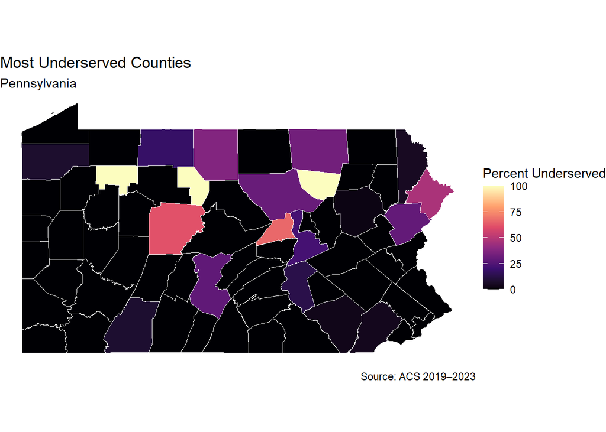

```r
# Spatial join tracts to counties
vulnerable_tracts <- vulnerable_tracts %>%
  mutate(NAMELSADCO = str_remove_all(NAMELSADCO, " County"))

vulnerable_tracts$NAMELSADCO <- toupper(vulnerable_tracts$NAMELSADCO)

vulnerable_tracts <- st_transform(vulnerable_tracts, crs = 4326)

pa_counties <- st_transform(pa_counties, crs = 4326)

county_tracts <- st_join(vulnerable_tracts, pa_counties, left = TRUE)

# Aggregate statistics by county
aggregate_summary <- county_tracts %>%
  st_drop_geometry() %>%
  group_by(NAMELSADCO) %>%
  summarize(
    number_vulnerable = sum(vulnerable),
    number_underserved = sum(underserved),
    percent_underserved = (number_underserved / number_vulnerable) * 100,
    avg_nearby_hospital_dist = mean(nearest_hospital_mi),
    total_vulnerable_pop = sum(total_popE)
  ) %>%
  rename(
    county = NAMELSADCO
  )

pa_counties <- rename(pa_counties, county = COUNTY_NAM)

pa_mapping <- left_join(pa_counties, aggregate_summary, by = "county")

ggplot(pa_mapping) +
  geom_sf(aes(fill = percent_underserved), color = "white", size = 0.5) +
  scale_fill_viridis_c(
    name = "Percent Underserved",
    labels = comma,
    option = "magma"
  ) +
  labs(
    title = "Most Underserved Counties",
    subtitle = "Pennsylvania",
    caption = "Source: ACS 2019–2023"
  ) +
  theme_void()
```

**Required county-level statistics:**

- Number of vulnerable tracts
- Number of underserved tracts
- Percentage of vulnerable tracts that are underserved
- Average distance to nearest hospital for vulnerable tracts
- Total vulnerable population

**Questions to answer:**

- Which 5 counties have the highest percentage of underserved vulnerable tracts?
  - Cameron (100%), Forest (100%), Sullivan (100%), Union (66.67%), and Clearfield (61.54%) counties.
- Which counties have the most vulnerable people living far from hospitals?
  - Counties with an average hospital distance of more than 15 miles and with the most vulnerable people in that group are Sullivan, Cameron, Forest, and Pike.
- Are there any patterns in where underserved counties are located?
  - It looks like more of the underserved counties are in the northern portion of Pennsylvania, and seemingly clustered toward the middle in addition. I also know those areas are peppered with several forested regions like national and state forests.

#### Step 7: Create Summary Table

Create a professional table showing the top 10 priority counties for healthcare investment.

**Your Task:**

```r
# Create and format priority counties table
kable_table <- pa_mapping[, c("county", "number_vulnerable",
                                "number_underserved", "percent_underserved",
                                "avg_nearby_hospital_dist", "total_vulnerable_pop")]

kable_table <- kable_table %>%
  mutate(
    avg_nearby_hospital_dist = drop_units(avg_nearby_hospital_dist)
  )

kable_table <- kable_table %>%
  st_drop_geometry() %>%
  rename(
    "County" = county,
    "Number of Vulnerable Tracts" = number_vulnerable,
    "Number of Underserved Tracts" = number_underserved,
    "Percent Underserved" = percent_underserved,
    "Average Mile(s) to Nearest Hospital" = avg_nearby_hospital_dist,
    "Total Vulnerable People" = total_vulnerable_pop
  )

kable_table <- kable_table %>%
  arrange(desc(`Percent Underserved`)) %>%
  slice(1:10)

kable(
  kable_table,
  digit = 2,
  format.args = list(big.mark = ","),
  caption = "<b>TOP 10 UNDERSERVED PENNSYLVANIA COUNTIES: For Priority Healthcare Investment</b>"
) %>%
  kable_styling(bootstrap_options = "striped") %>%
  column_spec(1, bold = TRUE) %>%
  row_spec(0, color = "mistyrose", background = "red3")
```

**TOP 10 UNDERSERVED PENNSYLVANIA COUNTIES: For Priority Healthcare Investment**

[output not shown]

**Requirements:**

- Use `knitr::kable()` or similar for formatting
- Include descriptive column names
- Format numbers appropriately (commas for population, percentages, etc.)
- Add an informative caption
- Sort by priority (you decide the metric)

## Part 2: Comprehensive Visualization

Using the skills from Week 3 (Data Visualization), create publication-quality maps and charts.

### Map 1: County-Level Choropleth

Create a choropleth map showing healthcare access challenges at the county level.

**Your Task:**

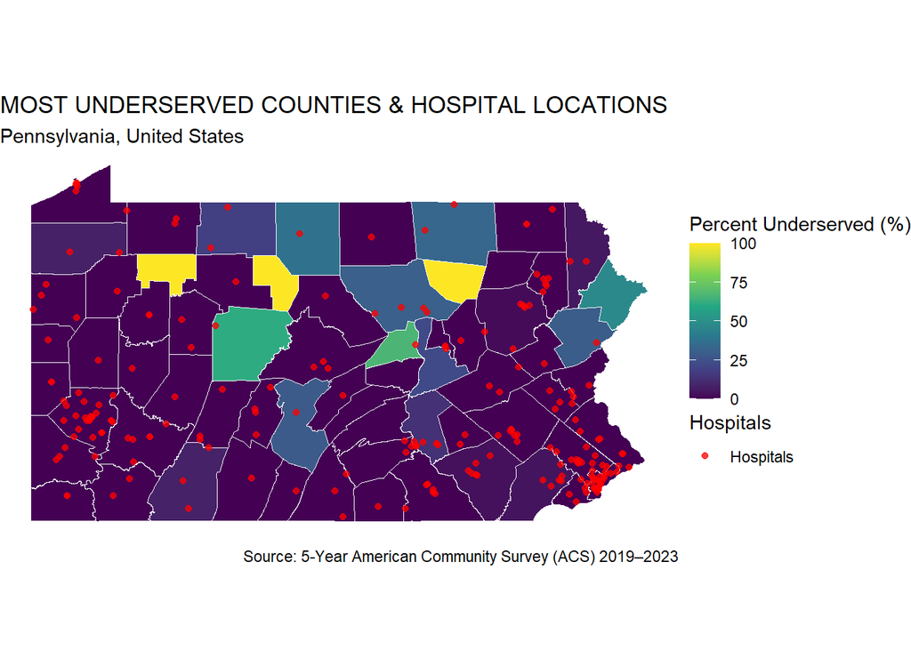

```r
# Create county-level access map
pa_hospitals <- st_transform(pa_hospitals, crs = 4326)
pa_mapping <- st_transform(pa_mapping, crs = 4326)

ggplot(pa_mapping) +
  geom_sf(
    aes(fill = percent_underserved),
    color = "white",
    size = 0.5
  ) +
  scale_fill_viridis_c(
    name = "Percent Underserved (%)",
    labels = scales::comma,
    option = "viridis"
  ) +
  geom_point(
    data = pa_hospitals,
    aes(x = LONGITUDE, y = LATITUDE, color = "Hospitals"),
    alpha = 0.75, inherit.aes = FALSE
  ) +
  scale_color_manual(
    name = "Hospitals",
    values = c("Hospitals" = "red")
  ) +
  labs(
    title = "MOST UNDERSERVED COUNTIES & HOSPITAL LOCATIONS",
    subtitle = "Pennsylvania, United States",
    caption = "Source: 5-Year American Community Survey (ACS) 2019–2023",
  ) +
  theme_void()
```

**Requirements:**

- Fill counties by percentage of vulnerable tracts that are underserved
- Include hospital locations as points
- Use an appropriate color scheme
- Include clear title, subtitle, and caption
- Use `theme_void()` or similar clean theme
- Add a legend with formatted labels

### Map 2: Detailed Vulnerability Map

Create a map highlighting underserved vulnerable tracts.

**Your Task:**

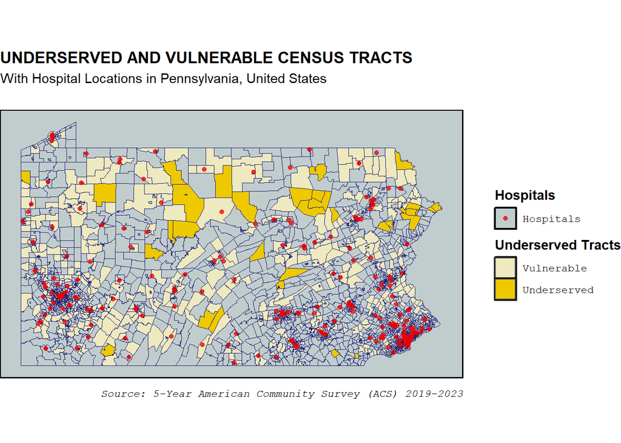

```r
# Create detailed tract-level map
vulnerable_tracts <- st_transform(vulnerable_tracts, crs = 4326)
pa_tracts <- st_transform(pa_tracts, crs = 4326)

vulnerable_tracts <- vulnerable_tracts %>%
  rename("Underserved Tracts" = underserved)

choropleth_map <- ggplot(vulnerable_tracts) +
  geom_sf(
    aes(fill = `Underserved Tracts`),
  ) +
  geom_sf(
    data = pa_tracts, fill = NA,
    color = "midnightblue", linewidth = 0.35
  ) +
  geom_point(
    data = pa_hospitals,
    aes(x = LONGITUDE, y = LATITUDE, color = "Hospitals"),
    alpha = 0.75, inherit.aes = FALSE
  ) +
  scale_fill_manual(
    name = "Underserved Tracts",
    values = c("TRUE" = "gold2", "FALSE" = "lemonchiffon2"),
    labels = c("TRUE" = "Underserved", "FALSE" = "Vulnerable")
  ) +
  scale_color_manual(
    name = "Hospitals",
    values = c("Hospitals" = "red2")
  ) +
  labs(
    title = "UNDERSERVED AND VULNERABLE CENSUS TRACTS",
    subtitle = "With Hospital Locations in Pennsylvania, United States",
    caption = "Source: 5-Year American Community Survey (ACS) 2019–2023",
  ) +
  theme_void()

choropleth_map + theme(
  panel.background = element_rect(fill = "azure3", size = 0.75),
  legend.box.margin = margin(l = 20, unit = "pt"),
  legend.title = element_text(face = "bold"),
  legend.text = element_text(family = "mono"),
  plot.title = element_text(face = "bold"),
  plot.subtitle = element_text(margin = margin(b = 20, t = 5, unit = "pt")),
  plot.caption = element_text(margin = margin(t = 10, unit = "pt"), face = "italic", family = "mono")
)
```

**Requirements:**

- Show underserved vulnerable tracts in a contrasting color
- Include county boundaries for context
- Show hospital locations
- Use appropriate visual hierarchy (what should stand out?)
- Include informative title and subtitle

### Chart: Distribution Analysis

Create a visualization showing the distribution of distances to hospitals for vulnerable populations.

**Your Task:**

```r
# Create distribution visualization
vulnerable_tracts$nearest_hospital_mi <- drop_units(vulnerable_tracts$nearest_hospital_mi)

histogram_hospital <- ggplot(vulnerable_tracts, aes(x = nearest_hospital_mi)) +
  geom_histogram()

histogram_hospital_log <- ggplot(vulnerable_tracts, aes(x = log(nearest_hospital_mi))) +
  geom_histogram(
    color = "black",
    fill = "mistyrose2"
  ) +
  labs(
    title = "HISTOGRAM: NATURAL LOG OF DISTANCE TO NEAREST HOSPITAL",
    x = "Natural Log of Distance to Nearest Hospital",
    y = "Count") +
  theme_minimal() +
  theme(aspect.ratio = 1/3)

histogram_elderly <- ggplot(vulnerable_tracts, aes(x = age_65_overE)) +
  geom_histogram(
    color = "black",
    fill = "mistyrose2"
  ) +
  labs(
    title = "HISTOGRAM: VULNERABLE POPULATION OF AGES 65+",
    x = "Population of Ages 65+",
    y = "Count") +
  theme_minimal() +
  theme(aspect.ratio = 1/3)

scatter_plot <- ggplot(vulnerable_tracts, aes(x = log(nearest_hospital_mi), y = age_65_overE)) +
  geom_point(
    aes(alpha = 0.5)) +
  geom_smooth(
    method = lm, linetype = "dashed",
    color = "red2", fill = "palegreen3") +
  labs(
    title = "SCATTER PLOT: HOSPITAL DISTANCE AND VULNERABLE POPULATION",
    subtitle = "Natural Log of Distance to Nearest Hospital vs. Population of Ages 65+\nwith Regression Line",
    caption = "Source: 5-Year American Community Survey (ACS) 2019–2023",
    x = "Natural Log of Distance to Nearest Hospital",
    y = "Population of Ages 65+") +
  theme(aspect.ratio = 4/3) +
  guides(alpha = "none")

faceted_plot <-
  (histogram_hospital_log + theme(
    plot.title = element_text(margin = margin(b = 10, unit = "pt"), face = "bold"),
    axis.title.x = element_text(margin = margin(t = 10, unit = "pt")),
    axis.title.y = element_text(margin = margin(r = 10, unit = "pt"))
  )) /
  (histogram_elderly + theme(
    plot.title = element_text(margin = margin(t = 20, b = 10, unit = "pt"), face = "bold"),
    axis.title.x = element_text(margin = margin(t = 10, unit = "pt")),
    axis.title.y = element_text(margin = margin(r = 10, unit = "pt"))
  )) /
  (scatter_plot + theme(
  legend.box.margin = margin(l = 20, unit = "pt"),
  legend.title = element_text(face = "bold"),
  legend.text = element_text(family = "mono"),
  plot.title = element_text(margin = margin(t = 20, unit = "pt"), face = "bold"),
  plot.subtitle = element_text(margin = margin(b = 10, t = 5, unit = "pt")),
  plot.caption = element_text(margin = margin(t = 10, unit = "pt"), face = "italic", family = "mono"),
  axis.title.x = element_text(margin = margin(t = 10, unit = "pt")),
  axis.title.y = element_text(margin = margin(r = 10, unit = "pt"))
  )) +
  plot_layout(heights = c(1, 1, 2))
```

```r
faceted_plot
```

[figure not shown]

**Suggested chart types:**

- Histogram or density plot of distances
- Box plot comparing distances across regions
- Bar chart of underserved tracts by county
- Scatter plot of distance vs. vulnerable population size

**Requirements:**

- Clear axes labels with units
- Appropriate title
- Professional formatting
- Brief interpretation (1-2 sentences as a caption or in text)
  - There’s an upward regression line that seems to communicate and positive correlation between distance to the nearest hospital and the vulnerable population. However, a more in-depth statistical analysis will be needed to determine any significance, especially since the vast majority of points look like they are varied from the regression line. The natural log of the distance histogram was calculated due to the original data being highly right-skewed.

## Part 3: Bring Your Own Data Analysis

Choose your own additional spatial dataset and conduct a supplementary analysis.

### Challenge Options

Choose ONE of the following challenge exercises, or propose your own research question using OpenDataPhilly data (https://opendataphilly.org/datasets/).

**Note these are just loose suggestions to spark ideas - follow or make your own as the data permits and as your ideas evolve. This analysis should include bringing in your own dataset, ensuring the projection/CRS of your layers align and are appropriate for the analysis (not lat/long or geodetic coordinate systems). The analysis portion should include some combination of spatial and attribute operations to answer a relatively straightforward question**

#### Education & Youth Services

**Option A: Educational Desert Analysis**

- **Data:** Schools, Libraries, Recreation Centers, Census tracts (child population)
- **Question:** “Which neighborhoods lack adequate educational infrastructure for children?”
- **Operations:** Buffer schools/libraries (0.5 mile walking distance), identify coverage gaps, overlay with child population density
- **Policy relevance:** School district planning, library placement, after-school program siting

**Option B: School Safety Zones**

- **Data:** Schools, Crime Incidents, Bike Network
- **Question:** “Are school zones safe for walking/biking, or are they crime hotspots?”
- **Operations:** Buffer schools (1000ft safety zone), spatial join with crime incidents, assess bike infrastructure coverage
- **Policy relevance:** Safe Routes to School programs, crossing guard placement

#### Environmental Justice

**Option C: Green Space Equity**

- **Data:** Parks, Street Trees, Census tracts (race/income demographics)
- **Question:** “Do low-income and minority neighborhoods have equitable access to green space?”
- **Operations:** Buffer parks (10-minute walk = 0.5 mile), calculate tree canopy or park acreage per capita, compare by demographics
- **Policy relevance:** Climate resilience, environmental justice, urban forestry investment

#### Public Safety & Justice

**Option D: Crime & Community Resources**

- **Data:** Crime Incidents, Recreation Centers, Libraries, Street Lights
- **Question:** “Are high-crime areas underserved by community resources?”
- **Operations:** Aggregate crime counts to census tracts or neighborhoods, count community resources per area, spatial correlation analysis
- **Policy relevance:** Community investment, violence prevention strategies

#### Infrastructure & Services

**Option E: Polling Place Accessibility**

- **Data:** Polling Places, SEPTA stops, Census tracts (elderly population, disability rates)
- **Question:** “Are polling places accessible for elderly and disabled voters?”
- **Operations:** Buffer polling places and transit stops, identify vulnerable populations, find areas lacking access
- **Policy relevance:** Voting rights, election infrastructure, ADA compliance

#### Health & Wellness

**Option F: Recreation & Population Health**

- **Data:** Recreation Centers, Playgrounds, Parks, Census tracts (demographics)
- **Question:** “Is lack of recreation access associated with vulnerable populations?”
- **Operations:** Calculate recreation facilities per capita by neighborhood, buffer facilities for walking access, overlay with demographic indicators
- **Policy relevance:** Public health investment, recreation programming, obesity prevention

#### Emergency Services

**Option G: EMS Response Coverage**

- **Data:** Fire Stations, EMS stations, Population density, High-rise buildings
- **Question:** “Are population-dense areas adequately covered by emergency services?”
- **Operations:** Create service area buffers (5-minute drive = ~2 miles), assess population coverage, identify gaps in high-density areas
- **Policy relevance:** Emergency preparedness, station siting decisions

#### Arts & Culture

**Option H: Cultural Asset Distribution**

- **Data:** Public Art, Museums, Historic sites/markers, Neighborhoods
- **Question:** “Do all neighborhoods have equitable access to cultural amenities?”
- **Operations:** Count cultural assets per neighborhood, normalize by population, compare distribution across demographic groups
- **Policy relevance:** Cultural equity, tourism, quality of life, neighborhood identity

### Data Sources

**OpenDataPhilly:** https://opendataphilly.org/datasets/

- Most datasets available as GeoJSON, Shapefile, or CSV with coordinates
- Always check the Metadata for a data dictionary of the fields.

**Additional Sources:**

- **Pennsylvania Open Data:** https://data.pa.gov/
- **Census Bureau (via tidycensus):** Demographics, economic indicators, commute patterns
- **TIGER/Line (via tigris):** Geographic boundaries

### Recommended Starting Points

**If you’re feeling confident:** Choose an advanced challenge with multiple data layers. **If you are a beginner, choose something more manageable that helps you understand the basics**

**If you have a different idea:** Propose your own question! Just make sure:

- You can access the spatial data
- You can perform at least 2 spatial operations

### Your Analysis

**Your Task:**

1. **Find and load additional data**
   - Document your data source
   - Check and standardize the CRS
   - Provide basic summary statistics

```r
# Load your additional dataset
```

**Questions to answer:**

Write a clear research statement that your analysis will answer.

**Examples:**

- “Do vulnerable tracts have adequate public transit access to hospitals?”
- “Are EMS stations appropriately located near vulnerable populations?”
- “Do areas with low vehicle access have worse hospital access?”
3. **Conduct spatial analysis**

Use at least TWO spatial operations to answer your research question.

**Required operations (choose 2+):**

- Buffers
- Spatial joins
- Spatial filtering with predicates
- Distance calculations
- Intersections or unions
- Point-in-polygon aggregation

**Your Task:**

```r
# Your spatial analysis
```

**Analysis requirements:**

- Clear code comments explaining each step
- Appropriate CRS transformations
- Summary statistics or counts
- At least one map showing your findings
- Brief interpretation of results (3-5 sentences)

## Finally - A few comments about your incorporation of feedback!

Take a few moments to clean up your markdown document and then write a line or two or three about how you may have incorporated feedback that you received after your first assignment.

## Submission Requirements

**What to submit:**

1. **Rendered HTML document posted to your course portfolio** with all code, outputs, maps, and text
   - Use `embed-resources: true` in YAML so it’s a single file
   - All code should run without errors
   - All maps and charts should display correctly

**File naming:** `LastName_FirstName_Assignment2.html` and `LastName_FirstName_Assignment2.qmd`